**Trial biostatistics toolkit**

OperationsBiostatisticsFull library

# Study Lifecycle Monitor

A visual, runnable guide to the operational-health console

**Run / share / read / build - pick your mode.** This page *shows* the console (diagrams + a live roll-up computed from the portfolio), the **run-and-build page** lets you *run* it and nudge a what-if, the dashboard is a shareable snapshot, and the run-and-build page shows how it is made. Synthetic, no PHI, no participant-level data. A screening lens for operational health, never a reported clinical number.

**A Shinylive build of the console, smoke-tested before each deploy.** Open it in your browser. It is the same R Shiny app, exported to run on R compiled to WebAssembly (Shinylive and webR) with no server: everything it needs loads from this site, and what you click stays in your browser. Synthetic data only. Before each deploy, the site’s publishing workflow opens it in headless Chrome as a first-time visitor and deploys nothing unless it starts, fills its panels with the expected values and shows no error ([run history](https://github.com/patrickiben/biometrics-ai-portfolio/actions/workflows/pages.yml)); the same check passed on a local build on 25 October 2026. Safari and Firefox are not checked.

**Before you open it:** R starts inside your browser, so the console takes several seconds to appear. The first visit downloads about 65 MB, shared with the other two apps on this site; later visits reuse the browser cache. It works best in Chrome or Edge; Safari support may vary. If it does not load, the screenshot below and the read-only snapshot show the same screens.

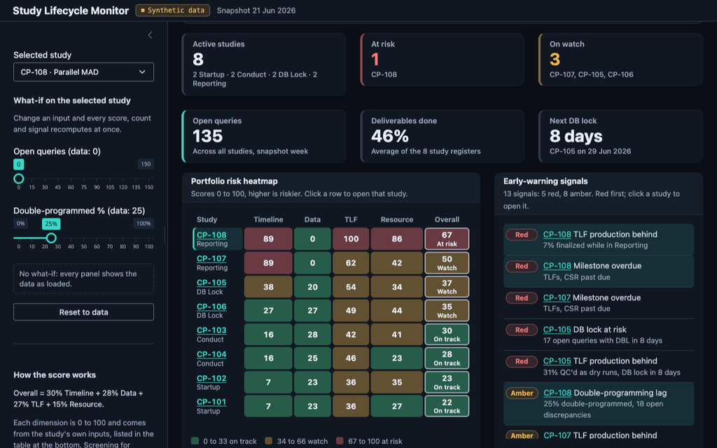

The console as it opens, on synthetic data.

## What it watches

Operational health of every study from protocol to CSR, on one screen: are milestones slipping, is the query backlog clearing before database lock, is TLF production keeping pace, is double-programming on track.

```
flowchart LR
  accTitle: Study lifecycle phases
  accDescr: Startup, conduct, database lock and reporting in sequence, with their milestones: protocol, SAP and first participant first visit; last participant last visit; database lock; TLFs and the CSR.
  S[Startup] --> C[Conduct] --> L[DB Lock] --> R[Reporting]
  S -.-> M1["Protocol<br/>SAP · FPFV"]
  C -.-> M2[LPLV]
  L -.-> M3[DBL]
  R -.-> M4["TLFs · CSR"]
```

## How the risk score works - it is transparent

No black box. Each study gets four operational sub-scores (0-100), blended into one:

```
flowchart LR
  accTitle: Operational risk score
  accDescr: Timeline, data, TLF and resource scores combine into an overall score, 0.30 T plus 0.28 D plus 0.27 F plus 0.15 R, which maps to red, amber or green bands.
  T["Timeline<br/>overdue + lock pressure"] --> O
  D["Data<br/>queries + clean/SDV"] --> O
  F["TLF<br/>finalized vs pressure"] --> O
  Rs["Resource<br/>double-prog + discrep"] --> O
  O{{"overall = 0.30·T + 0.28·D<br/>+ 0.27·F + 0.15·R"}}
  O --> RAG["RAG bands<br/>red · amber · green"]
```

Because it is a formula, you can defend every number and change what “risk” means in one place (`score_study()` in `R/logic.R`).

## The live portfolio - computed from the data

Everything below is rendered from four CSVs, the same files the Shiny app reads: `studies.csv`, `milestones.csv`, `deliverables.csv`, and `query_trend.csv` (in the `shiny/data/` folder). Edit those CSVs (or run the app) and these move.

8

Active studies

1

At risk

3

On watch

135

Open queries

46%

Avg deliverables

8d

Next DB lock

**Risk heatmap**

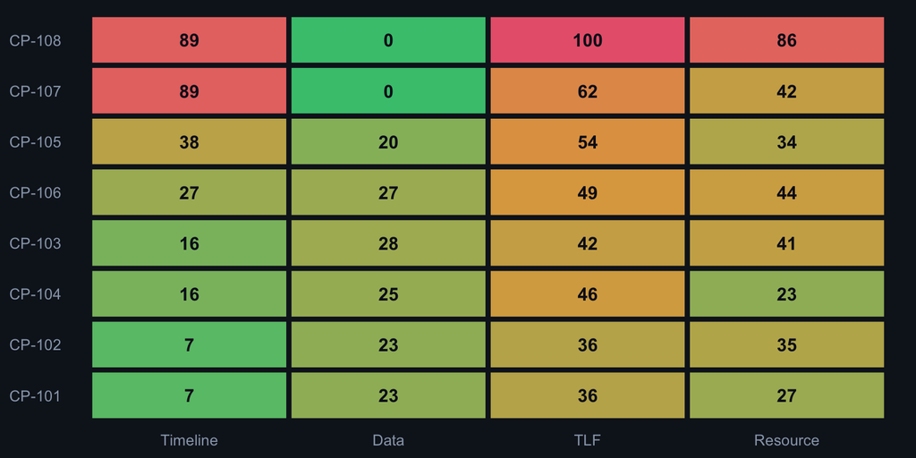

**Ranked signals**

| Severity | Study | Signal | Detail |
| --- | --- | --- | --- |
| red | CP-108 | TLF production behind | 7% finalized while in Reporting |
| red | CP-108 | Milestone overdue | TLFs, CSR past due |
| red | CP-107 | Milestone overdue | TLFs, CSR past due |
| red | CP-105 | DB lock at risk | 17 open queries with DBL in 8 days |
| red | CP-105 | TLF production behind | 31% QC’d as dry runs, DB lock in 8 days |
| amber | CP-108 | Double-programming lag | 25% double-programmed, 18 open discrepancies |
| amber | CP-107 | TLF production behind | 44% finalized while in Reporting |
| amber | CP-107 | Double-programming lag | 55% double-programmed, 7 open discrepancies |
| amber | CP-105 | Double-programming lag | 43% double-programmed, 2 open discrepancies |
| amber | CP-106 | DB lock at risk | 38 open queries with DBL in 16 days |

## Run it - and change it

```r
shiny::runApp("lifecycle_dashboard/shiny")
# needs: install.packages(c("shiny","bslib","ggplot2"))
```

Pick a study, then move the what-if sliders (open queries, double-programming) and watch that study’s row in the heatmap re-color. The run-and-build page shows how the app is built from `R/logic.R`.

**Going live:** `R/gen_data.R` writes the four CSVs (`studies.csv`, `milestones.csv`, `deliverables.csv`, `query_trend.csv`) so you can see the shape. Replace them with a read-only CTMS / EDC export carrying the same columns and the console is your portfolio. Nothing writes back to a source system.

## The other formats

| Mode | Artifact |
| --- | --- |
| Run | Run & build the Shiny app |
| Share (no R) | Dashboard |
| Build | Run-and-build walkthrough |

*Synthetic, deterministic, no PHI. Operational screening, not a clinical readout.*